# Reproducible Research: Peer Assessment 1

## Loading and preprocessing the data

For the following code to work it is required that the gitHub repository https://github.com/rdpeng/RepData_PeerAssessment1 has been cloned **into your working directory**, and that the file *activity.zip* is found there. First we load the file *activity.csv* into R and assign the contents to the variable *activity*. Then we look at the structure of *activity*.

```r
unzip("activity.zip")
activity <- read.csv("activity.csv")
str(activity)
```

```
## 'data.frame':    17568 obs. of  3 variables:
##  $ steps   : int  NA NA NA NA NA NA NA NA NA NA ...
##  $ date    : Factor w/ 61 levels "2012-10-01","2012-10-02",..: 1 1 1 1 1 1 1 1 1 1 ...
##  $ interval: int  0 5 10 15 20 25 30 35 40 45 ...
```

The variable *date* is currently handled as a factor. So we convert it to the date-format.

```r
activity$date <- as.Date(as.character(activity$date))
```

## What is mean total number of steps taken per day?

In order to calculate the total number of steps per day, the *dplyr*-package is loaded. The dataframe *activity* is then grouped by date and summarized with the sum of steps per day assigned to the variable *sum*. Lastly, a plot is created using the base plotting-package with *type = h*, which plots the data as histogram-like vertical lines.

```r
library(dplyr)
```

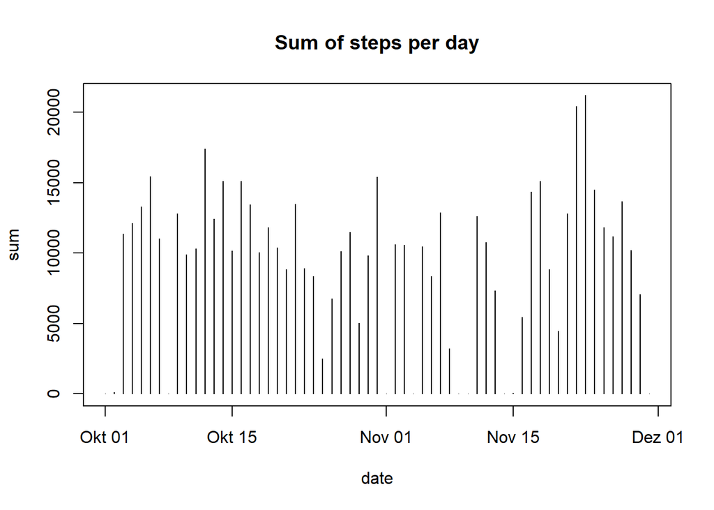

```r
sum_steps <- activity %>% group_by(date) %>% summarize(sum = sum(steps, na.rm = TRUE))
plot(sum_steps, type = "h", main = "Sum of steps per day")
```

Then we calculate the mean and median of the total number of steps taken per day.

```r
act_mean <- mean(sum_steps$sum)
act_med <- median(sum_steps$sum)
```

The mean number of steps per day is 9354.2295082, the median is 10395.

## What is the average daily activity pattern?

Here, again, we group the dataframe *activity*, but this time by the variable *interval*. We then summarize it with the mean of steps per interval assigned to the variable *mean*. This new dataframe is then plotted with *type* set to *“l”*.

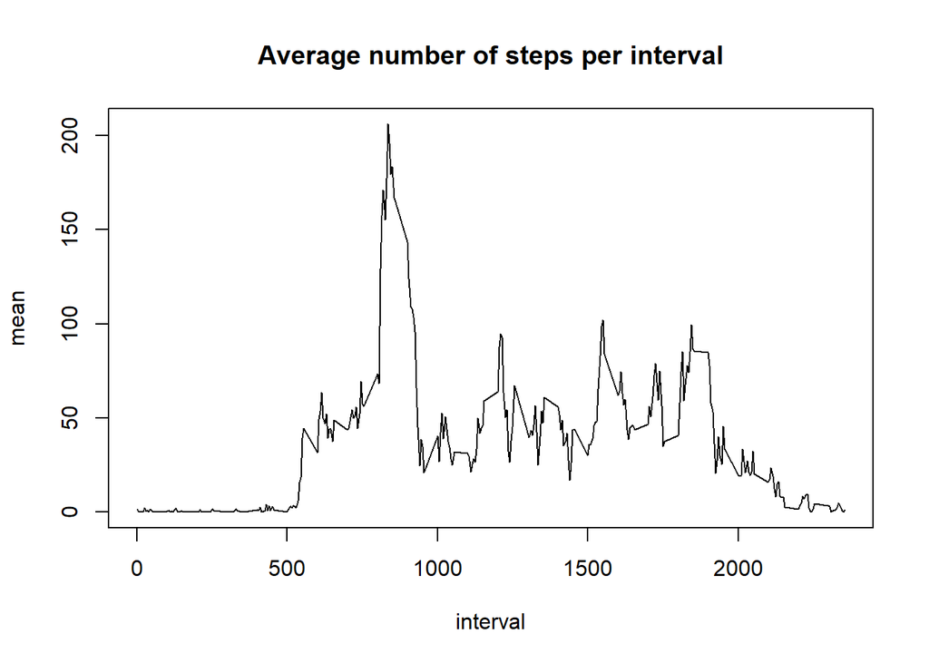

```r
av_steps <- activity  %>% group_by(interval) %>% summarize(mean = mean(steps, na.rm = TRUE))
plot(av_steps, type = "l", main = "Average number of steps per interval")
```

Next we compute the 5-minute interval, on average across all the days in the dataset, which contains the maximum number of steps:

```r
head(arrange(av_steps, desc(mean)),1)
```

```
## # A tibble: 1 x 2
##   interval  mean
##      <int> <dbl>
## 1      835  206.
```

We learn that interval 835 contains the highest number of steps.

## Imputing missing values

First, we calculate the number of missing values per variable.

```r
colSums(is.na(activity))
```

```
##    steps     date interval
##     2304        0        0
```

Apparently, missing values only appear in the variable *steps* and there are 2304 of them.

In order to fill in all of the missing values in the dataset, i decide to replace them with the average number of steps across all days for the given interval. These steps are performed on the new dataset *activity2*, which is created as an exact copy of *activity*:

```r
activity2 <- activity
for (i in 1:nrow(activity2)) {
  if(is.na(activity2[i,1])) activity2[i,1] = mean(subset(activity2, interval == activity2[i,3])[,1], na.rm = TRUE)
}
```

We calculate and plot the total number of steps per day as previously, only this time with imputed missing values, so we use the dataset *activity2*:

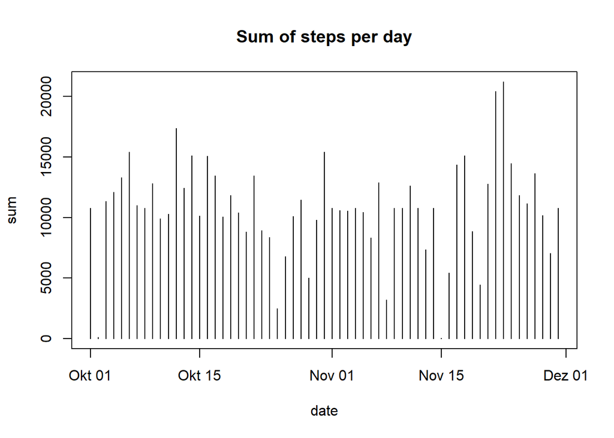

```r
sum_steps2 <- activity2 %>% group_by(date) %>% summarize(sum = sum(steps))
plot(sum_steps2, type = "h", main = "Sum of steps per day")
```

Again, we calculate the mean and median of the total number of steps taken per day.

```r
act_mean2 <- mean(sum_steps2$sum)
act_med2 <- median(sum_steps2$sum)
```

```r
summary(sum_steps2$sum)
```

```
##    Min. 1st Qu.  Median    Mean 3rd Qu.    Max.
##      41    9819   10766   10766   12811   21194
```

## Are there differences in activity patterns between weekdays and weekends?

We create a new factor variable in the dataset with two levels - “weekday” and “weekend” - indicating whether a given date is a weekday or weekend day. First, we create a character-vector containing the abbreviated weekdays in German.

```r
weekday <- c("Mo","Di","Mi","Do","Fr")
```

Then we add a fourth column “Day” to the dataset *activity2* which is converted to a factor.

```r
for (i in 1:nrow(activity2)) {
  if(weekdays(activity2[i,2], abbreviate = TRUE) %in% weekday) (activity2[i,4] = "weekday")
    else activity2[i,4] = "weekend"
}
activity2$V4 <- as.factor(activity2$V4)
activity2 <- rename(activity2, Day = V4)
str(activity2)
```

```
## 'data.frame':    17568 obs. of  4 variables:
##  $ steps   : num  1.717 0.3396 0.1321 0.1509 0.0755 ...
##  $ date    : Date, format: "2012-10-01" "2012-10-01" ...
##  $ interval: int  0 5 10 15 20 25 30 35 40 45 ...
##  $ Day     : Factor w/ 2 levels "weekday","weekend": 1 1 1 1 1 1 1 1 1 1 ...
```

We see that the new variable *Day* is indeed a factor with the two levels “weekday” and “weekend”.

Now we create two datasets, one for weekdays only, one for weekends only, where each contains the average number of steps per interval.

```r
weekday_mean <- activity2 %>% filter(Day == "weekday") %>% group_by(interval) %>% summarize(mean = mean(steps))
weekend_mean <- activity2 %>% filter(Day == "weekend") %>% group_by(interval) %>% summarize(mean = mean(steps))
```

Lastly, we create two time series plots of the 5-minute interval and the average number of steps taken, averaged across all weekday days or weekend days:

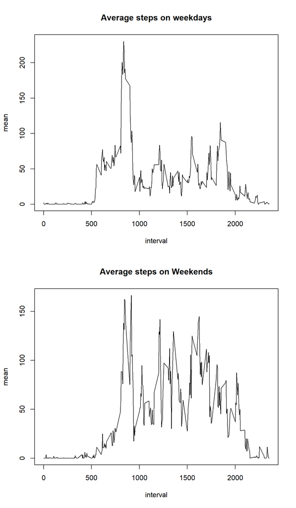

```r
par(mfrow = c(2,1))
plot(weekday_mean, type="l", main = "Average steps on weekdays")
plot(weekend_mean, type="l", main = "Average steps on Weekends")
```